# Superstore Sales Analysis

Rashi Katoch

2026-07-08

# Superstore Sales Analysis

# Introduction

This project analysis Superstore sales data using R programming. The analysis includes sales trend, customer performance, category-wise analysis, regional analysis, profit analysis, and a 12-month sales forecast using the ARIMA model.

## Data Overview The Superstore dataset contains 10,194 records and 21 variables. It includes information about order, customers, products, sales, profit, discounts, shipping details, and regions. The dataset is used to analyze business performance and identify sales trends.

## Data Cleaning The dataset was imported R and checked for missing values and data types. The Order.Date column was converted into Date format to enable time series analysis. The data was then prepared for visualization and forecasting.

## Sales Analysis Sales and profit are important indicators of business performance. The scatter plot below shows the relationship between sales and profit across all orders.

Sales and profit are important indicators of business performance. The scatter plot below shows the relationship between sales and profit across all orders.

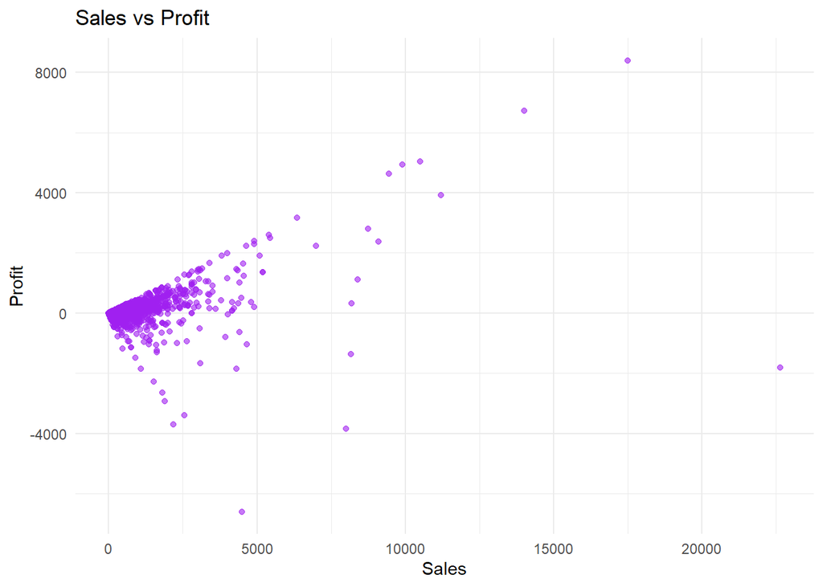

```r
ggplot(data, aes(x = Sales, y = Profit)) +
  geom_point(color = "purple", alpha = 0.6) +
  labs(
    title = "Sales vs Profit",
    x = "Sales",
    y = "Profit"
  ) +
  theme_minimal()
```

## Customer Analysis The customer analysis identifies the top customers based on total sales. This helps businesses recognize their most valuable customers and improve customer relationship strategies.

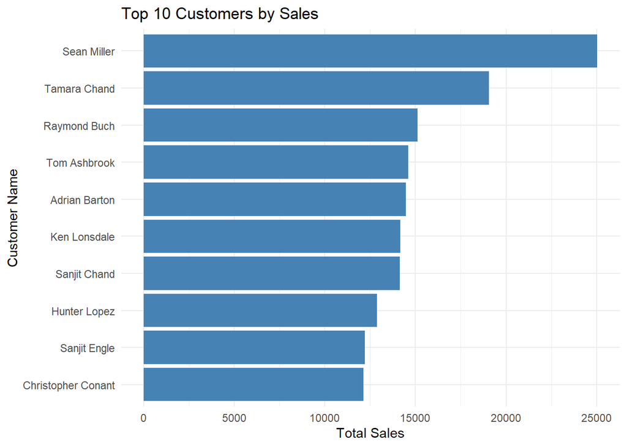

```r
top10_customers <- aggregate(Sales ~ Customer.Name, data = data, sum)

top10_customers <- top10_customers[
  order(top10_customers$Sales, decreasing = TRUE),
]

top10_customers <- head(top10_customers, 10)

library(ggplot2)

ggplot(top10_customers,
       aes(x = reorder(Customer.Name, Sales), y = Sales)) +
  geom_col(fill = "steelblue") +
  coord_flip() +
  labs(
    title = "Top 10 Customers by Sales",
    x = "Customer Name",
    y = "Total Sales"
  ) +
  theme_minimal()
```

## Category Analysis The category analysis compares total sales across different product categories. IT helps identify which category contributes the highest sales and supports business decision-making.

```r
 category_sales <- data %>% group_by(Category)%>%
 summarise(Sales = sum (Sales))
```

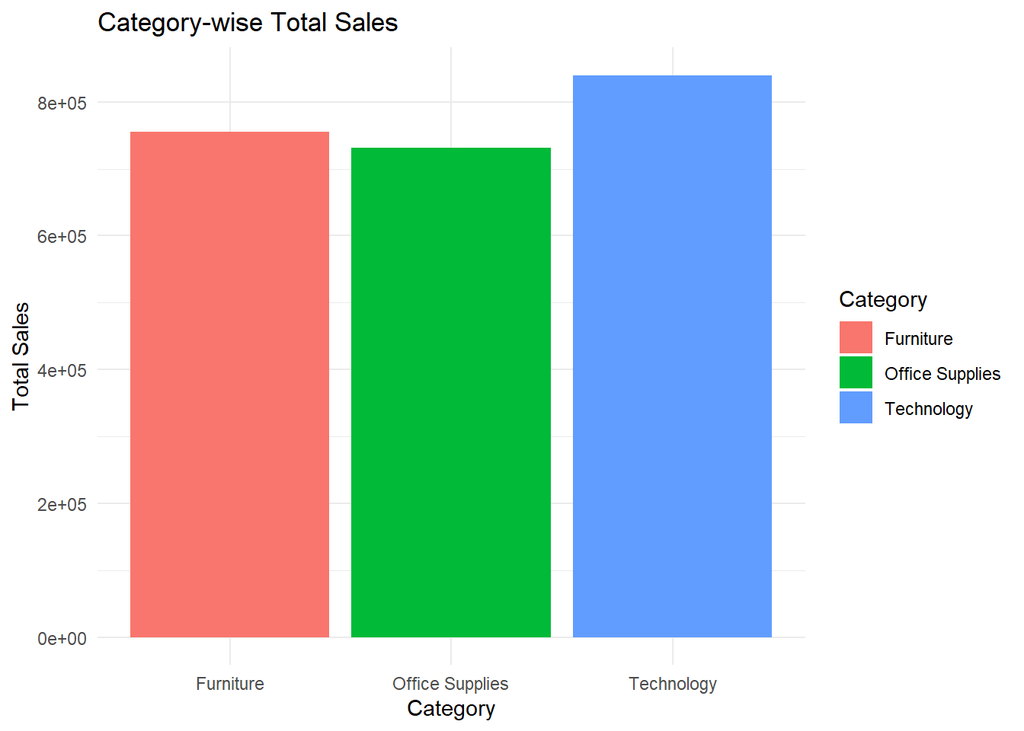

```r
 ggplot(category_sales,aes(x = Category , y = Sales, fill = Category)) +
  geom_col() + labs(title = "Category-wise Total Sales",
                     x = "Category",
                     y = "Total Sales") +
   theme_minimal()
```

## Regional Analysis The regional analysis compares total profit across different regions. It helps identify the most profitable regions and supports better business decision-making.

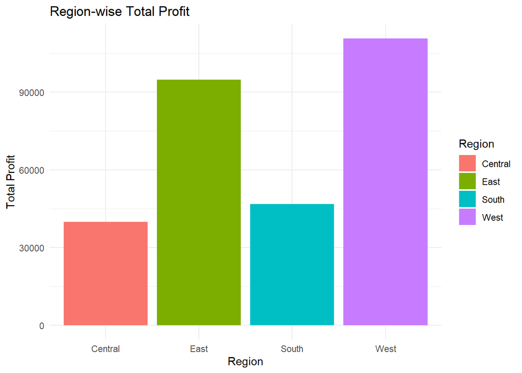

```r
region_profit <- data%>%
  group_by(Region) %>%
  summarise(Profit = sum(Profit))
 ggplot(region_profit,aes(x = Region , y = Profit, fill = Region)) +
   geom_col() + labs(title = "Region-wise Total Profit",
                     x = "Region",
                     y = "Total Profit") +
   theme_minimal()
```

## Monthly sales Trend The monthly sales trend shows how total sales changed over time. This analysis helps identify seasonal patterns, business growth, and fluctuations in sales performance.

```r
 # convert order Date to Date format---

  data$Order.Date <- as.Date(data$Order.Date, format ="%m/%d/%Y")
  head(data$Order.Date)
```

```
## [1] "2023-01-03" "2023-01-04" "2023-01-04" "2023-01-04" "2023-01-05"
## [6] "2023-01-06"
```

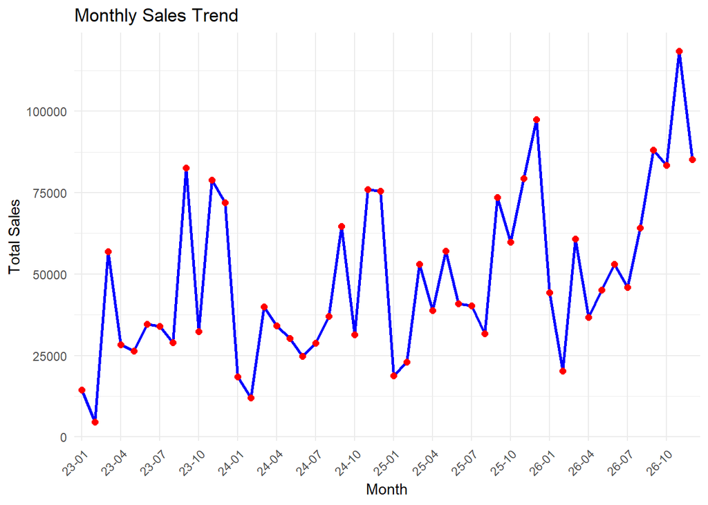

```r
  # Monthly Sales Trend---

  monthly_sales <- data %>% mutate (Month =
                                  format(Order.Date,"%y-%m"))%>%
    group_by(Month) %>%
    summarise(Total_Sales = sum(Sales), .Groups = "drop")

  ggplot(monthly_sales, aes(x = Month, y = Total_Sales, group = 1)) +
    geom_line(color = "blue", linewidth = 1) + geom_point(color = "red",
                                                          size = 2) +
    labs(title = "Monthly Sales Trend",x = "Month",
         y = "Total Sales") +
    scale_x_discrete(breaks = monthly_sales$Month[seq(1,
                                                      nrow(monthly_sales),
                                                      by = 3)])+
    theme_minimal() +
    theme(axis.text.x = element_text(angle = 45, hjust = 1))
```

## Sales Forecast The sales forecast predicts the expected sales for the next 12 months using the ARIMA time series forecasting model. The forecast helps businesses estimate future demand and support planning and decision-making.

```r
# Convert Monthly Sales to Time Series---
  ts_sales <- ts(monthly_sales$Total_Sales, frequency = 12)
   # Display Time series----
  ts_sales
```

```
##          Jan        Feb        Mar        Apr        May        Jun        Jul
## 1  14518.055   4519.892  56933.909  28295.345  26319.767  34669.480  33946.393
## 2  18461.916  11951.411  39978.628  34195.209  30246.947  24797.292  28765.325
## 3  18830.331  22978.815  53031.069  38829.159  57042.838  40937.148  40300.499
## 4  44259.214  20301.133  60728.481  36779.036  45155.482  53056.078  45989.496
##          Aug        Sep        Oct        Nov        Dec
## 1  28918.339  82670.429  32413.339  78826.957  72008.308
## 2  37057.004  64627.046  31407.133  75972.564  75532.557
## 3  31716.814  73521.663  59831.001  79411.966  97502.277
## 4  64129.758  88064.532  83474.783 118454.505  85175.033
```

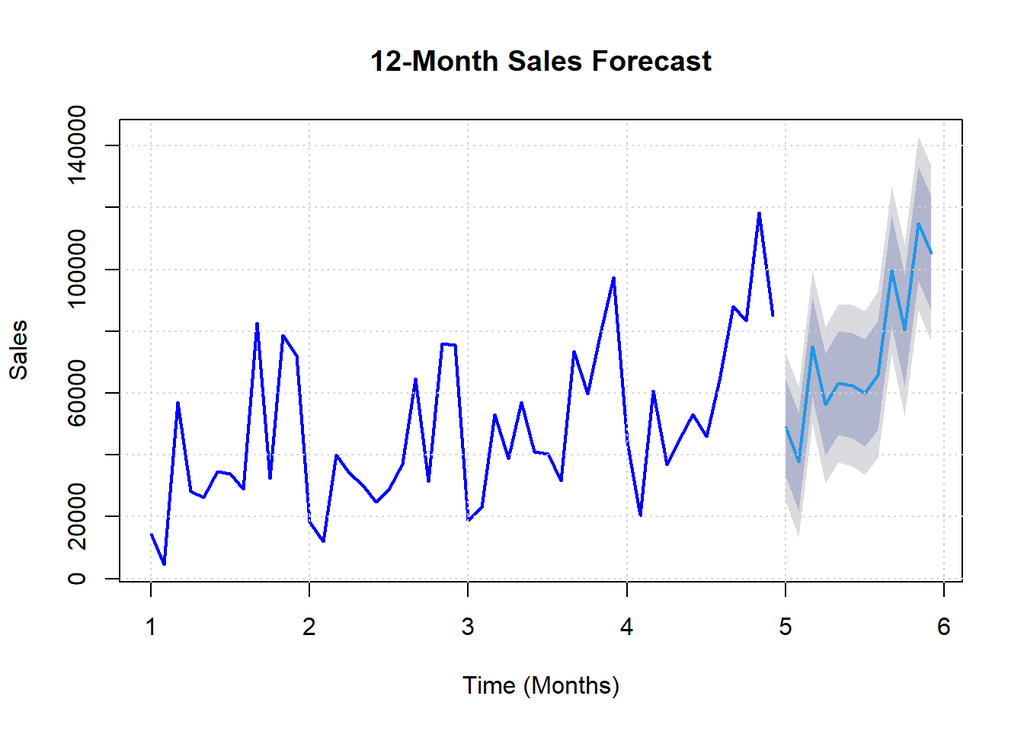

```r
  # Build Forecast Model----
  forecast_model <- auto.arima(ts_sales)

 # Forecast Next 12 month---
  sales_forecast <- forecast(forecast_model, h = 12)

 plot(sales_forecast, main = "12-Month Sales Forecast",
                                 xlab = "Time (Months)",
                                 ylab = "Sales",
                             col = "blue",
                             lwd = 2
       )

  grid(col ="lightgray", lty = "dotted")
```

## conclusion This project analyzed the Superstore Sales dataset using R programming. The analysis included data cleaning, exploratory data analysis,customer analysis, and time series forecasting.

Overall, this project demonstrates how R can be used to transform raw business data into meaningful insights that support data-driven decision-making.